# Harvard CS109A | Lecture 3: Introduction to Regression kNN and Linear Regression

Key Word(s): Knn, Knn Regression, MSE, Data Plotting

Download Notebook

## Description :

The aim of this exercise is to **plot** TV Ads vs Sales based on the Advertisement dataset which should look similar to the graph given below.

[figure not shown]

## Instructions:

- Read the Advertisement data and view the top rows of the dataframe to get an understanding of the data and the columns.
- Select the first 7 observations and the columns `TV` and `Sales` to make a new data frame.
- Create a scatter plot of the new data frame `TV` budget vs `Sales`.

## Hints:

[pd.read_csv(filename)](https://pandas.pydata.org/pandas-docs/stable/reference/api/pandas.read_csv.html) Returns a pandas dataframe containing the data and labels from the file data

df.iloc[] Returns a subset of the dataframe that is contained in the row range passed as the argument

np.linspace() Returns evenly spaced numbers over a specified interval

df.head() Returns the first 5 rows of the dataframe with the column names

plt.scatter() A scatter plot of y vs. x with varying marker size and/or color

plt.xlabel() This is used to specify the text to be displayed as the label for the x-axis

plt.ylabel() This is used to specify the text to be displayed as the label for the y-axis

**Note:** This exercise is auto-graded and you can try multiple attempts.

```python
# Import necessary libraries
import pandas as pd
import matplotlib.pyplot as plt
%matplotlib inline
```

### Reading the Advertisement dataset

```python
# "Advertising.csv" containts the data set used in this exercise
data_filename = 'Advertising.csv'

# Read the file "Advertising.csv" file using the pandas library
df = pd.read_csv("Advertising.csv")
```

```python
# Get a quick look of the data
df.describe()
```

|  | TV | Radio | Newspaper | Sales |
| --- | --- | --- | --- | --- |
| count | 200.000000 | 200.000000 | 200.000000 | 200.000000 |
| mean | 147.042500 | 23.264000 | 30.554000 | 14.022500 |
| std | 85.854236 | 14.846809 | 21.778621 | 5.217457 |
| min | 0.700000 | 0.000000 | 0.300000 | 1.600000 |
| 25% | 74.375000 | 9.975000 | 12.750000 | 10.375000 |
| 50% | 149.750000 | 22.900000 | 25.750000 | 12.900000 |
| 75% | 218.825000 | 36.525000 | 45.100000 | 17.400000 |
| max | 296.400000 | 49.600000 | 114.000000 | 27.000000 |

```python
### edTest(test_pandas) ###
# Create a new dataframe by selecting the first 7 rows of
# the current dataframe
df_new = df.head(7)
```

```python
# Print your new dataframe to see if you have selected 7 rows correctly
print(df_new)
```

```
      TV  Radio  Newspaper  Sales
0  230.1   37.8       69.2   22.1
1   44.5   39.3       45.1   10.4
2   17.2   45.9       69.3    9.3
3  151.5   41.3       58.5   18.5
4  180.8   10.8       58.4   12.9
5    8.7   48.9       75.0    7.2
6   57.5   32.8       23.5   11.8
```

### Plotting the graph

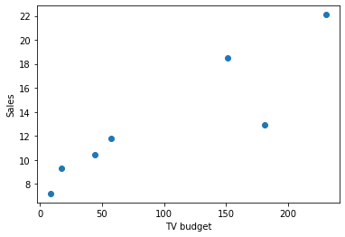

```python
# Use a scatter plot for plotting a graph of TV vs Sales
plt.scatter(df_new.TV, df_new.Sales)

# Add axis labels for clarity (x : TV budget, y : Sales)
plt.xlabel("TV budget")
plt.ylabel("Sales")
```

## Post-Exercise Question

Instead of just plotting seven points, experiment to plot all points.

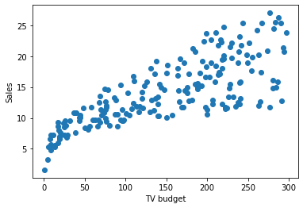

```python
# Your code here
plt.scatter(df.TV, df.Sales)

# Add axis labels for clarity (x : TV budget, y : Sales)
plt.xlabel("TV budget")
plt.ylabel("Sales")
```